# Tutorial 1. Pre-processing ATAC-seq QC

Iguaracy Souza and Umran YAMAN

Compiled: 2024-02-25

### Background:

Recent studies have identified numerous non-coding loci associated with Alzheimer’s disease (AD) risk, yet their underlying mechanisms and the transcriptional regulatory circuitry specific to AD remain poorly elucidated. In this investigation, we conducted a comprehensive analysis of the epigenomic and transcriptomic landscapes in 850,000 nuclei derived from AD and healthy prefrontal cortex tissues of 92 individuals. Our aim was to construct a detailed map of the brain regulome, encompassing epigenomic profiles, transcriptional regulators, co-accessibility modules, and peak-to-gene links in a cell-type-specific context. To achieve this, we devised novel methods for multimodal integration and the identification of regulatory modules through peak-to-gene linking. Our findings reveal an enrichment of AD risk loci in microglial enhancers and implicate specific transcription factors, such as SPI1, ELF2, and RUNX1. Additionally, we identified 9,628 cell-type-specific ATAC-QTL loci, which, when integrated with peak-to-gene links, allowed us to prioritize regulatory circuits associated with AD variants. Notably, we observed differential accessibility in regulatory modules, with glia showing changes in late-stage AD and neurons exhibiting alterations in early-stage AD. Strikingly, late-stage AD brains displayed a global dysregulation of the epigenome, indicative of epigenomic erosion and loss of cell identity.

### Dataset

```r
suppressPackageStartupMessages({
    library(zellkonverter)  # For cell type annotation
    library(ggplot2)  # For data visualization
    library(reticulate)  # For Python integration
    library(SingleCellExperiment)
    library(AnnotationDbi)
    library(org.Hs.eg.db)
    library(EnsDb.Hsapiens.v86)
    library(scater)  # Single-cell analysis tools
    library(Matrix)
    library(Seurat)  # Single-cell data integration and analysis
    library(DoubletFinder)  # Identifying doublets in single-cell datasets
    library(dplyr)
    library(Signac)  # Tools for single-cell epigenomics
    library(biovizBase)  # Base functions for bioviz packages
})
```

### Downsampling process

```r
# Converting from Python to R Load data Read the h5ad file
scRNA_ATAC_brain <- readRDS("../data/PeakMatrix.TSS6.cleaned.rds")

# Check cell type information
metadata <- as.data.frame(colData(scRNA_ATAC_brain))
table(colData(scRNA_ATAC_brain)$Celltype1)
```

```
##
##       Ast        Ex        In Microglia     Oligo       OPC   PerEndo
##     10066     22380     20631      8550    101059      7235      1198
```

```r
## downsample by 5% by cell type
set.seed(123)  # For reproducibility
downsampled_cells <- lapply(split(colnames(scRNA_ATAC_brain), colData(scRNA_ATAC_brain)$Celltype1),
    function(cells) {
        sample(cells, size = ceiling(length(cells) * 0.05))
    })

# Flatten the list to get a vector of cell names
downsampled_cells <- unlist(downsampled_cells)

scRNA_ATAC_brain_downsampled_data <- scRNA_ATAC_brain[, downsampled_cells]
# Check the dimensions of the downsampled data
dim(scRNA_ATAC_brain_downsampled_data)
```

```
## [1] 363775   8558
```

```r
# Check the new distribution of cell types
table(colData(scRNA_ATAC_brain_downsampled_data)$Celltype4)
```

```
##
##       Ast        Ex        In Microglia     Oligo       OPC   PerEndo
##       508      1121      1025       428      5052       362        62
```

```r
#########


### Convert RangedSummarizedExperiment to seurat object


# Extract the counts matrix again
counts <- assay(scRNA_ATAC_brain_downsampled_data, "PeakMatrix")

# Create a new Seurat object
scRNA_ATAC_brain_seurat <- CreateSeuratObject(counts = counts)

# Add metadata (if needed)
metadata <- as.data.frame(colData(scRNA_ATAC_brain_downsampled_data))
rownames(metadata) <- colnames(scRNA_ATAC_brain_seurat)
scRNA_ATAC_brain_seurat@meta.data <- metadata

# Extract genomic ranges and create a Chromatin Assay
granges <- rowRanges(scRNA_ATAC_brain_downsampled_data)
# get gene annotations for hg38
annotation <- GetGRangesFromEnsDb(ensdb = EnsDb.Hsapiens.v86)
seqlevels(annotation) <- paste0("chr", seqlevels(annotation))
genome(annotation) <- "hg38"
chrom_assay <- CreateChromatinAssay(counts = counts, ranges = granges, genome = "hg38", annotation = annotation)
scRNA_ATAC_brain_seurat[["ATAC"]] <- chrom_assay
```

```r
# we can put the link to the dropbox here as well. They can directly download it as rds
# scRNA_ATAC_brain_seurat_QC <- readRDS('../data_to_delete/scATAC_brain_downsampled_data.rds')
DefaultAssay(scRNA_ATAC_brain_seurat) <- "ATAC"
```

### TSS Enrichment Score and QC Plots

TSS (Transcription Start Site) enrichment scores and quality control plots are generated to assess the distribution and enrichment of peaks around transcription start sites. These plots help evaluate the quality and reliability of the ATAC-seq data by examining the distribution of peaks relative to TSS.

The DensityScatter() function enables visualization of the connections between variables stored in the object metadata. Additionally, it serves as a rapid tool for identifying appropriate cutoff values for various quality control (QC) metrics when quantiles=TRUE is specified

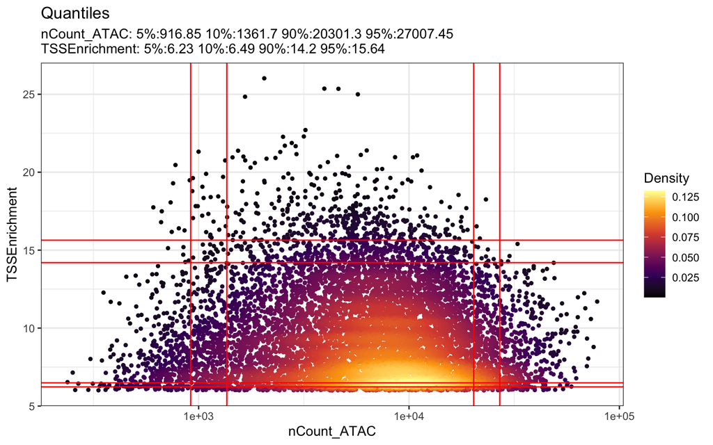

```r
DensityScatter(scRNA_ATAC_brain_seurat, x = "nCount_ATAC", y = "TSSEnrichment", log_x = TRUE, quantiles = TRUE)
```

### QC Metrics Violin Plot

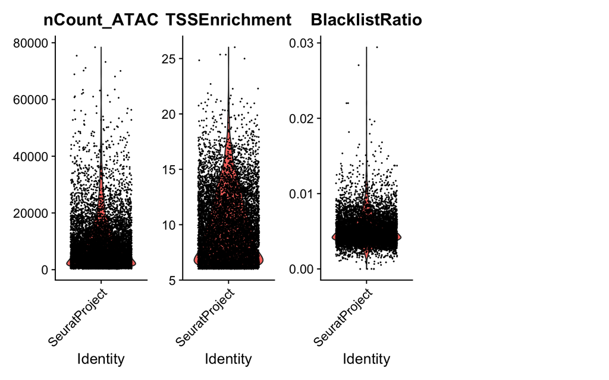

```r
# QC Metrics Violin Plot
VlnPlot(object = scRNA_ATAC_brain_seurat, features = c("nCount_ATAC", "TSSEnrichment", "BlacklistRatio"),
    pt.size = 0.1, ncol = 5)
```